# 3.4_DSSD_front_back_correlation_1

## 3.4 DSSD front-back correlation (I)

### 目的：

1. 掌握利用正背面关联进行能量刻度的方法
2. ROBUST fit

### Front-back correlation neglecting crosstalks

- 入射粒子产生的载流子在漂移过程中，在正负极上产生等量异号的感应电荷。
- 在两侧采用不同极性的主放大器，可以得到幅度相同的正信号。
- 即有, $E_i = E_j$

[figure not shown]

### correlation

- 粒子在入射位置为：xstrip=i条、ystrip=j条，标记为$(i,j)$
- 对于入射到 $(i,j)$ ，能量沉积为E的粒子,x,y侧记录的信号道值为 $A_i,A_j$:

$$ E_i=m_iA_i+n_i \\ E_j=p_jA_j+q_j \\ $$

$$ E=E_i=E_j => A_i=k_{ij}A_j+b_{ij} $$

上式中 $k_{ij}, b_{ij}$ 称为$A_j$相对于$A_i$的归一化系数。称$i$条为参考条。

上图右侧显示了$A_i与A_j$的二维关联图，可以看出二者呈现很好的线性关系，利用上式进行线性拟合即可确定$k_{ij},b_{ij}系数$。

### 正面和背面能量的线性关联关系，是排除无关事件、确定入射位置的重要条件

- 在有多个入射粒子同时入射时，依赖于正背面关联关系确定各入射粒子的位置
  - 如两个粒子入射,实际入射位置和能量分别为：

[figure not shown]

    - 粒子1：$(x_1,y_1)$,$(e_{x1},e_{y1})$，粒子2：$(x_2,y_2)$,$(e_{x2},e_{y2})$
    - 可能的入射组合为$(x_1,y1),(x_2,y_2)；(x_1,y_2),(x_2,y_1)$
  - 通过选择能量相近的组合，可以排除入射位置的不确定性。
  - 进行上述步骤时，必须先进行能量刻度

## ROOT File : data_16C.root

- Reaction: $25MeV/A \quad ^{16}C+^{9}Be$, 测量16C在靶上碎裂后的多重带电粒子产物。
- Detector setup: 3个DSSD+CSI的望远镜阵列，放置靶后零角度方向，朝向束流。
  - D1[32x32]- D2[32x32]- D3[32x32]
    - 条宽：2mm，条间距：0.1mm
  - SSD[2]
  - CSI[2x2]

[figure not shown]

- Geometry:
  - target:
    - $\phi=30mm$
    - z=0
  - D1:
    - z=156mm
  - D2:
    - z=176mm
  - D3:
    - z=196mm
- Trigger: 要求D1和D2的x面，同时有两根条以上有信号( M2=Multiplicity$\ge$ 2)：
  - $D1M2 \bigotimes D2M2$
- 事件预处理：
  - 事件满足时间cut：去除x方向信号的偶然符合事件(y方向没有记录时间）

### Branch:

```
// xenergy, yenergy, xtime
    d1x[32], d1y[32], d1t[32];
    d2x[32], d2y[32], d2t[32];
    d3x[32], d3y[32], d3t[32];
//hit, energy, time, strip
    d1xhit, d1xe[d1xhit], d1xt[d1xhit], d1xs[d1xhit];
    d2xhit, d2xe[d2xhit], d2xt[d2xhit], d2xs[d2xhit]
    d3xhit, d3xe[d3xhit], d3xt[d3xhit], d3xs[d3xhit]

    d1yhit, d1ye[d1yhit], d1yt[d1yhit], d1ys[d1yhit];
    d2yhit, d2ye[d2yhit], d2yt[d2yhit], d2ys[d2yhit]
    d3yhit, d3ye[d3yhit], d3yt[d3yhit], d3ys[d3yhit]
```

```python
//%jsroot on
TFile *ipf = new TFile("data_16C.root");
TTree *tree = (TTree*)ipf->Get("tree");
TCanvas *c1=new TCanvas("c1","c1");
```

### hit结构中事件已按照能量降低的顺序排序

```python
tree->Scan("d1xe:d1xs:d1ye:d1ys","","",10,1);
```

```
*    Row   * Instance *      d1xe *      d1xs *      d1ye *      d1ys *
*        1 *        0 *      4800 *        17 *      5775 *        18 *
*        1 *        1 *       982 *        18 *           *           *
*        2 *        0 *      3069 *        23 *      3352 *        11 *
*        2 *        1 *       341 *        24 *       111 *        10 *
*        3 *        0 *      5325 *        23 *      4522 *        15 *
*        3 *        1 *           *           *       922 *        16 *
*        4 *        0 *      5822 *        21 *      5688 *        15 *
*        4 *        1 *           *           *       271 *        14 *
*        5 *        0 *      4048 *        11 *      5213 *        12 *
*        5 *        1 *      1149 *        12 *           *           *
*        6 *        0 *      3719 *        14 *      4255 *        16 *
*        6 *        1 *       374 *        13 *           *           *
*        7 *        0 *      4546 *        12 *      4961 *         9 *
*        7 *        1 *       297 *        11 *           *           *
*        8 *        0 *      4051 *        22 *      3877 *         9 *
*        8 *        1 *           *           *       329 *        10 *
*        9 *        0 *      6720 *        13 *      6513 *        12 *
*        9 *        1 *       142 *        10 *       418 *        13 *
*        9 *        2 *       109 *        14 *           *           *
*       10 *        0 *      3873 *        20 *      3007 *         8 *
*       10 *        1 *           *           *       974 *         9 *
```

### inter-strip correlation

- 一般情况下，条间事件的比例 = 条间面积/探测器灵敏面积
- 本实验中，由于触发的原因，相邻条能量共享事件的比例大大增加。

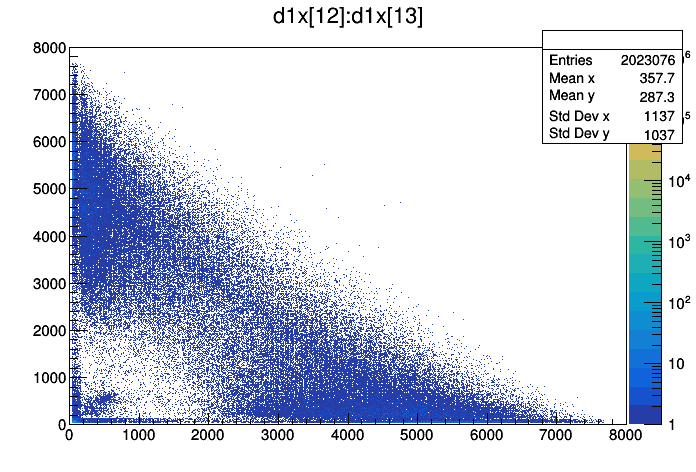

```python
tree->Draw("d1x[12]:d1x[13]>>(1000,0,8000,1000,0,8000)","","colz");//inter-strip correlation
gPad->SetLogz();
c1->Draw();
```

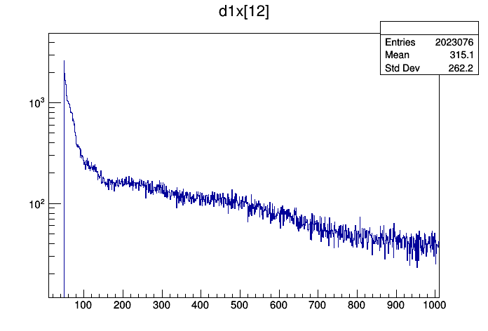

```python
tree->Draw("d1x[12]>>(1000,10,1010)","","colz");
gPad->SetLogy();
c1->Draw();
```

## front-back correlation

- 由于x面和y面有相邻条之间的能量共享，可以看到中间直线区域(front-back)外有很多散点的分布。

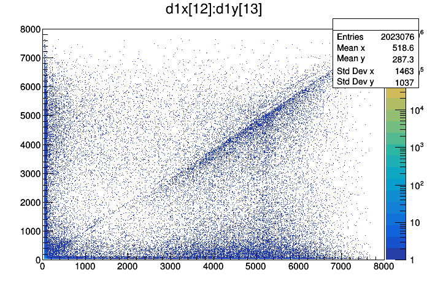

```python
gPad->SetLogy(0);
tree->Draw("d1x[12]:d1y[13]>>(1000,0,8000,1000,0,8000)","","colz");
c1->Draw();//front-back correlation
```

### 要求两侧只有一重信号

- 散点减少。
- 显示不同条的能量刻度系数不一致，需要刻度。

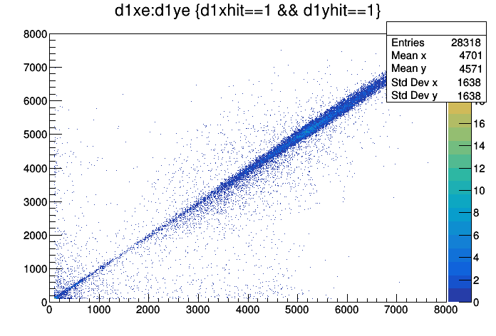

```python
//所有x条和y条正背面关联，都选择一重事件
TCut chit="d1xhit==1 && d1yhit==1";
tree->Draw("d1xe:d1ye>>(1000,0,8000,1000,0,8000)",chit,"colz");
gPad->SetLogz(0);
c1->Draw();
```

### x面，y面各选定某一条，并且两侧只有一重信号

- 条件太严格，导致统计太少

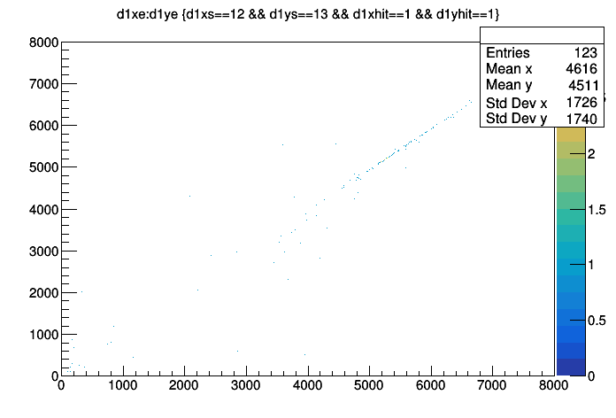

```python
TCut chit1="d1xs==12 && d1ys==13 && d1xhit==1 && d1yhit==1";
tree->Draw("d1xe:d1ye>>(1000,0,8000,1000,0,8000)",chit1,"colz");
c1->Draw();
```

### 改进的关联条件

- 获取的条件为某一面的hit=2，因此事件中hit=1的事件很少。
  - 在前期的数据处理过程中，去掉了一些不满足时间条件的信号，导致有些x面事件的多重性由2降为1。
- 改进的条件：不对多重性作限制，而只要求x和y面相邻条没有共享信号。

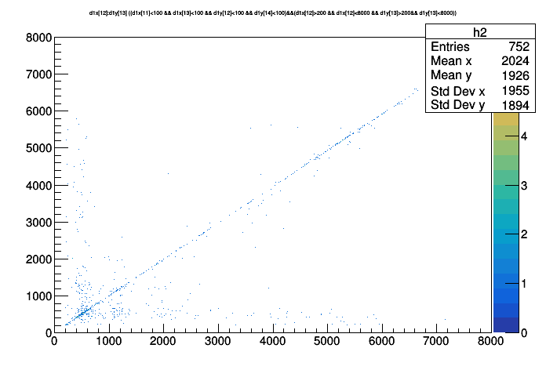

```python
TCut cveto="d1x[11]<100 && d1x[13]<100 && d1y[12]<100 && d1y[14]<100";//no crosstalk from neighbouring strips
TCut c1213="d1x[12]>200 && d1x[12]<8000 && d1y[13]>200&& d1y[13]<8000";
tree->Draw("d1x[12]:d1y[13]>>h2(1000,0,8000,1000,0,8000)",cveto&&c1213,"colz");//front-back correlation with crosstalk rejection
c1->Draw();
```

### TH2转成TGraph进行拟合

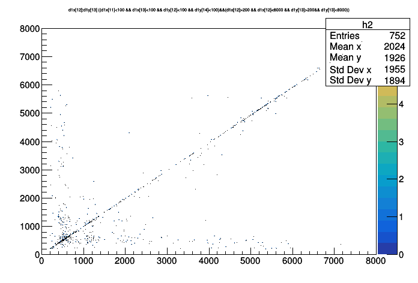

```python
TGraph *gr = new TGraph(tree->GetSelectedRows(),tree->GetV2(), tree->GetV1());
gr->Draw("p");//draw point
c1->Draw();
```

```
Minimizer is Linear
Chi2                      =   1.1529e+09
NDf                       =          750
p0                        =       442.64   +/-   65.0783
p1                        =     0.732927   +/-   0.0231293
```

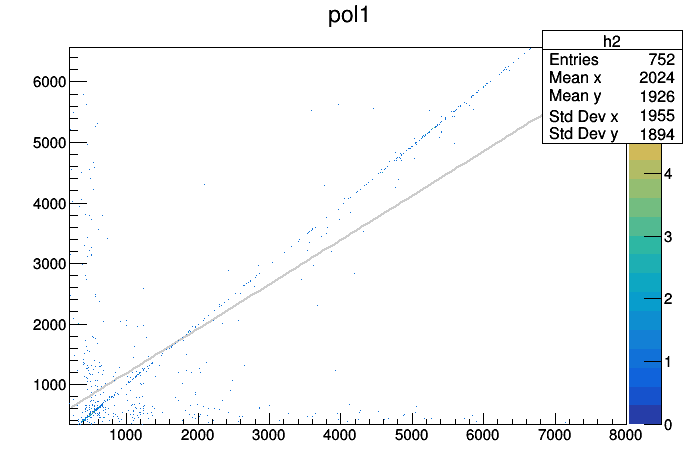

```python
TF1 *fp1= new TF1("fp1","pol1",200,8000);
fp1->SetLineColor(kGray);
gr->Fit(fp1);
fp1->Draw();
h2->Draw("same colz");
c1->Draw();
```

### 拟合结果与直觉不符！

- 在直线外存在大量散点(outliers,不是由于统计涨落引起的，是由于其他机制导致的)，影响拟合结果。
- 可以通过人为选择拟合区域(TCutG)，改善拟合。但这取决于cut范围，拟合结果随着cut范围变化而变化。

### ROBUST REGRESSION

In the presence of outliers that do not come from the same data-generating process as the rest of the data, least squares estimation is inefficient and can be biased. Robust regression methods are designed to be not overly affected by violations of assumptions by the underlying data-generating process. common situation in which robust estimation is used occurs when the data contain outliers. https://root.cern.ch/root/html/tutorials/fit/fitLinearRobust.C.html

[figure not shown]

- ROOT 只支持多项式的Robust fitting

```python
Double_t p0,p1,p2;
```

```
Minimizer is Linear / Robust
Chi2                      =  1.33686e+09
NDf                       =          750
p0                        =      16.4611
p1                        =     0.982673
```

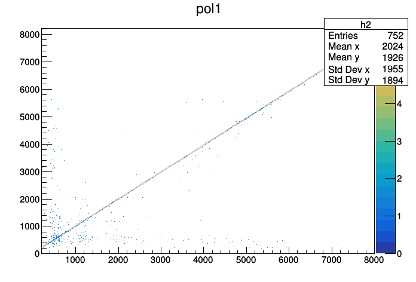

```python
gr->Fit(fp1,"ROB");
   //The option "rob=0.75" means that we want to use robust fitting and
   //we know that at least 75% of data is good points (at least 50% of points
   //should be good to use this algorithm). If you don't specify any number
   //and just use "rob" for the option, default value of (npoints+nparameters+1)/2
   //will be taken
p0=fp1->GetParameter(0);
p1=fp1->GetParameter(1);
fp1->Draw();
h2->Draw("same colz");
c1->Draw();
```

### 观察残差分布

- 一次多项式拟合的残差分布不是随机的。

```python
TString stree;
```

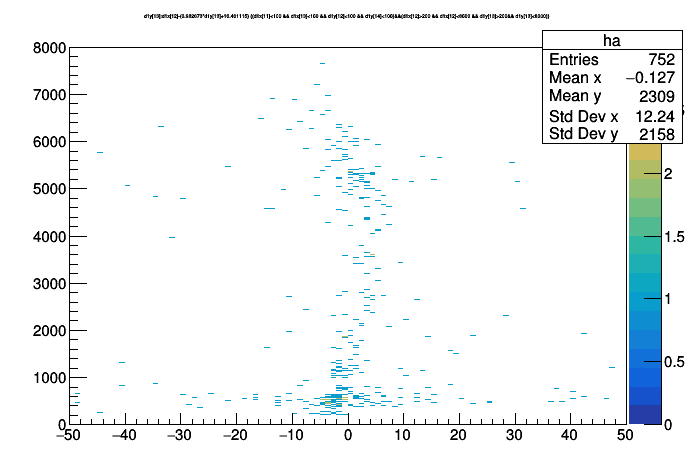

```python
stree.Form("d1y[13]:d1x[12]-(%lf*d1y[13]+%lf)>>ha(100,-50,50,1000,0,8000)",p1,p0);//%lf-Double_t
tree->Draw(stree.Data(),cveto&&c1213,"colz");//front-back correlation with crosstalk rejection
c1->Draw();//从图上看，一次函数拟合并不是很好
```